# Métodos Estatísticos: Uma Visão Geométrica

Felipe Cordeiro Melo

# 1 Introdução

A Estatística é uma ciência muito ampla, porém muito pouco explorada ainda, existem várias formas de soluções para os mais simples problemas e uma dessas formas é o método geométrico. De início pode parecer que isso só vai complicar algo simples, mas a geometria consegue explicar de forma muito mais fácil para a compreensão de como os dados se comportam e como as técnicas estatísticas tentam explicá-los, então esse Post tem como objetivo demonstrar ideias básicas da estatística com o método geométrico para uma população única.

Para melhor entendimento e visualização dos conceitos, utlizaremos um exemplo com uma amostra de tamanho $2$ gerada aleatoriamente de uma população normal com $\mu = 0$ e $\sigma = 1$:

```
## [1] -0.56 -0.23
```

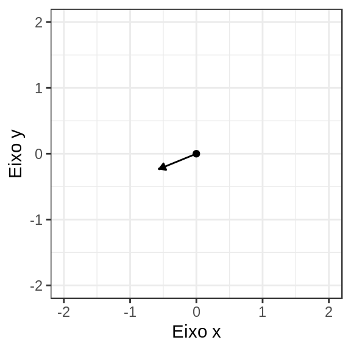

# 2 Conceitos Iniciais

Primeiramente, precisamos definir alguns conceitos da Álgebra Linear, que serão muito importantes para a compreensão desse método.

## 2.1 Tamanho de um Vetor

Como o próprio título já diz, precisamos saber como calcular o tamanho de um vetor, é um conceito básico da Álgebra Linear, mas que nos ajudará bastante em várias partes do método, como por exemplo, nos testes de hipóteses.

Dado um vetor $v = v_1, v_n, \dots, v_n$, o seu tamanho será dado pela expressão:

$$||v|| = \sqrt{v_1^2 + v_2^2 + \dots + v_n^2}$$

## 2.2 Vetor Unitário

É um vetor de tamanho $1$, precisaremos transformar o vetor das observações em um modelo da média e dos erros, portanto, esse definição é primordial para o uso do método, talvez a mais importante e utilizada dentro dele.

Dado um vetor $v = v_1, v_n, \dots, v_n$, o vetor unitário correspondente a ele será obtido através da expressão:

$$U = \frac{v}{||v||}$$

O vetor unitário do exemplo é:

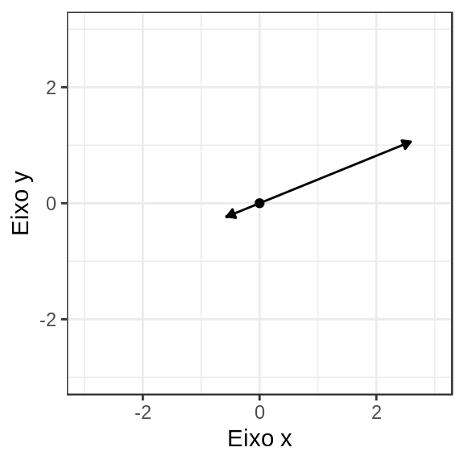

Podemos ver que o vetor unitário mantém a mesma direção do vetor $v$, portanto nem sempre com o mesmo sentido, e com um tamanho diferente.

## 2.3 Vetor Média

É a projeção do vetor de observação em um vetor na forma $U_1 = \frac{1}{\sqrt{n}}\left[1, 1, 1, \dots \right]$, ou seja, $(y.U_1)U_1$, terá tamanho $(y.U_1)$, na direção de $U_1$.

$U_1 = \frac{1}{\sqrt{2}}\left[1, 1 \right]$

$y.U_1 = <y, U_1> = -0.56\times \frac{1}{\sqrt2} -0.23\times\frac{1}{\sqrt2} = -0.5586$

$(y.U_1)U_1 = -0.5586 \times \frac{1}{\sqrt{2}}\left[1, 1 \right] = \left[-0.395, -0.395\right]$

Podemos ver então que $(y.U_1)U_1 = \hat{\mu}$, a média da amostra.

## 2.4 Sistema de Vetores Ortogonais

Vetores serão ortogonais entre si quando o ângulo interno deles for igual a 90°, isso será importante na modelagem do espaço dos erros, para conseguirmos usar o Teorema de Pitágoras como veremos mais a seguir.

# 3 O Método Geométrico

Ele é composto por 3 objetos, os **dados**, o **modelo**, e as **hipóteses**, através deles iremos utilizar processos que nos ajudarão a chegar nos testes estatísticos.

## 3.1 Dados

O primeiro passo do nosso estudo é saber como vamos usar os dados coletados. Eles serão organizados em um único vetor, cada elemento da amostra é um elemento do vetor, ou seja, eles serão estudados em um espaço de dimensão $n$ (o tamanho da amostra), portanto a visualização do modelo fica impossível em amostras em que $n > 3$.

## 3.2 Modelo

É o espaço que irá conter $n$ vetores ortogonais entre si, serão distribuídos como o vetor de média, e subespaço dos vetores dos erros, que tem dimensão $n-1$, ele será dessa forma porque temos

$$y = \bar{y} + (y - \bar{y})$$

Essa forma de escrever o vetor das observações será útil na construção da ANOVA para assim fazermos os testes estatísticos e obtermos estimações para os parâmetros da população.

## 3.3 Hipótese

Geralmente, as hipóteses são as seguintes:

$H_0: \mu = 0$

$H_1: \mu \neq 0$

Se $F_{cal} > F_{1, n-1}$, então rejeita-se $H_0$, caso contrário, não se rejeita $H_0$. Em que o valor de $F_{1, n-1}$ é dado pela tabela $\textit{F de Snedecor}$ com $1$ e $n-1$ graus de liberdade e um valor de confiança $1 - \alpha$.

# 4 Projeções

A projeção é a parte mais cansativa e complicada do método geométrico, isso porque precisaremos de $n$ vetores unitários ortogonais entre si, que irão projetar o vetor das observações em $n$ direções no espaço, o primeiro vetor será o vetor das médias que já foi obtido anteriormente, agora para obtermos o subespaço dos erros usaremos a seguinte forma:

$$U_n = \frac{1} {\sqrt{n(n - 1)}}\left[\begin{array}
{ccc}
1 \\
1 \\
1 \\
\vdots \\
-(n-1)
\end{array}\right]$$

Mesmo dessa forma é um processo bastante exaustivo sendo que precisamos calcular um a um, a melhor solução para um $n$ consideravelmente grande seria usufruir da tecnologia a nosso favor. Para o nosso exemplo, o subespaço dos erros é contido por apenas um vetor, então será de fácil obtenção.

$$U_2 = \frac{1} {\sqrt{2}}\left[\ 1, -1 \right]$$

Projetando o vetor das observações no subespaço dos erros:

$y.U_2 = <y, U_2> = -0.56\times \frac{1}{\sqrt2} -0.23\times\frac{-1}{\sqrt2} = -0.233$

$(y.U_2)U_2 = -0.233 \times \frac{1}{\sqrt{2}}\left[1, -1 \right] = \left[-0.165, 0.165\right]$

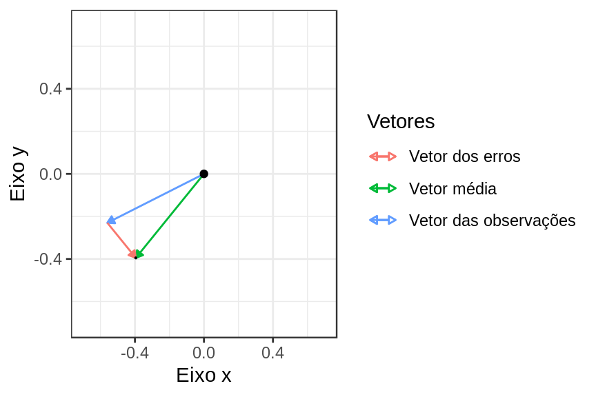

Podemos observar que eles formam um triângulo retângulo, então podemos utilizar o Teorema de Pitágoras para os testes como veremos a seguir.

# 5 Testes de Hipóteses

Para calcularmos os testes de hipóteses utilizaremos a tabela da ANOVA que terá resultados obtidos através de um dos teoremas mais conhecidos da matemática, o Teorema de Pitágoras, da seguinte forma:

$y = \bar{y} + (y - \bar{y})$

$||y||^2 = ||\bar{y}||^2 + ||y - \bar{y}||^2$

$||y||^2 = (y.U_1)^2 + (y.U_2)^2 + \dots + (y.U_n)^2$

A demonstração dessa igualdade é um pouco extensa, mas ela se da pelo fato de que como o sistema do vetor média e os vetores dos erros são ortogonais, num espaço $n$, eles vão criando entre si $n$ triângulos retângulos que no final irão formar a “hipotenusa” $y$, o vetor das observações.

## 5.1 Anova

| Causas | GL | SQ | QM | F |
| --- | --- | --- | --- | --- |
| Média | 1 | SQMédia | QMMédia | QMMédia/QMRes |
| Resíduos | n-1 | SQRes | QMRes |  |
| Total | n | SQTotal |  |  |
| em que: |  |  |  |  |

SQMédia $= ||\bar{y}||^2$

SQRes $= ||y - \bar{y}||^2$

QMMédia $= ||\bar{y}||^2$

QMRes $= \frac{||y - \bar{y}||^2}{n - 1}$

Portanto, iremos testar se o quadrado do tamanho do vetor média é significativo em relação a média dos quadrados do espaço dos erros. Podemos observar que o QMRes será um estimador para a variância dos dados.

A ANOVA para o exemplo será:

| Causas | GL | SQ | QM | F |
| --- | --- | --- | --- | --- |
| Média | 1 | 0.312 | 0.312 | 5.778 |
| Resíduos | 1 | 0.054 | 0.054 |  |
| Total | 2 | 0.366 |  |  |

Com um nível de confiança de $95$%:

$F_{1, 1} = 161.4$, ou seja, $F_{tab} > F_{cal}$, então não rejeita-se a hipótese nula de que $\mu = 0$.

# 6 Considerações Finais

Apesar de ser um método que pode se tornar cansativo e trabalhoso, ele nos ajuda a ter uma visão diferente de como usamos a estatística, que é algo importante em todas as áreas do conhecimento, saber lidar com formas diferentes do padrão, e além disso ele pode ser usado em análise de experimentos, na comparação de duas populações. Desde que o tamanho da amostra não seja muito grande, esse método pode ser útil no dia a dia.

# 7 Referências

SAVILLE, David J.; WOOD, Graham R. Statistical Methods: The Geometric Approach. New York: Springer Science & Business Media, 1991.

SAVILLE, David J.; WOOD, Graham R. Statistical Methods: A Geometric Primer. New York: Springer Science & Business Media, 1996.